# HWS7 – Practice Reproducibility Project No. 1

Jeffrey A. Walker

10/14/2021

# Part I Gut microorganisms act together to exacerbate inflammation in spinal cords

The assignment is: reproduce the analysis of the experiment presented in Fig 1G of the article

[Miyauchi, Eiji, et al. “Gut microorganisms act together to exacerbate inflammation in spinal cords.” Nature 585.7823 (2020): 102-106.](https://www.nature.com/articles/s41586-020-2634-9)

dataset: Miyauchi-2020-fig1f,g-gut-microorganisms.xlsx

You need to 1) import the data, 2) analyze the data, and 3) report the results following the example in [Section 10.1.1](https://www.middleprofessor.com/files/applied-biostatistics_bookdown/_book/oneway#oneway-example1)

About the data: The data file contains the percent of cells expressing the genes ki67+ and CD4+ in Fig 1F and the total number of CD4+ T cells in Fig 1G. ki67 is expressed prior to cell division (its a “marker” for cell division). CD4 is expressed on Helper T cells (its a “marker” for helper T cells) – a type of lymphocyte that functions in the adaptive immune response.

The researchers are interested in the role of intestinal bacteria on the development of autoimmune diseases and have a mouse model for the autoimmune disease **multiple sclerosis** by inducing experimental autoimmune encephalomyelitis (EAE). The goal of the paper is to explore connections between intestinal bacteria, the immune response to these bacteria, and the development of multiple sclerosis like phenotypes. In the experiments in Fig 1, the researchers are measuring the effect of induced EAE on different immune responses. Fig. 1F, G is looking at the response on CD4+ T cells and especially CD4+ T cells that also express ki67.

Response variable:

1. Fig 1F: Percentage of CD4+ T cells.
2. Fig 1G: Number of CD4+ T cells. **ONLY analyze Fig 1G**

**Note**. Percentage and count data can never be normally distributed but they can sometimes look like data that were sampled from a normal distribution. This is a good example of the debate in the Ecology literature of using more advanced methods (generalized linear models) that we’ll learn in a few weeks or using the simpler methods (general linear models) that we’re using now.

The treatment factor in the experiment reported in Fig. 1F, G has three levels

1. Naive – Mice that have not been induced to develop EAE. The researchers expect the percentage/counts to be low.
2. Control – Mice that have been induced to develop EAE (the model for multiple sclerosis). The researchers expect the percentage/counts to be high.
3. Amp – EAE mice given the antibiotic ampicillin, which kills the bacteria that induce EAE. The researchers expect to see percentage/counts lower than the control, given results earlier in figure.

Assignment:

1. Write out all contrasts and which are of interest and which are not, and why for both.

Control - Naive. This is the positive control. Just making sure the mice show signs of EAE.

Amp - Control. The focal contrast

Amp - Naive. Could be interested if want to quantify recue.

```r
data_from <- "Gut microorganisms act together to exacerbate inflammation in spinal cords"
file_name <- "Miyauchi-2020-fig1f,g-gut-microorganisms.xlsx"
file_path <- here(data_folder, data_from, file_name)
fig1f <- read_excel(file_path,
                    sheet = "Fig 1f",
                    range = "A1:B19") %>%
  clean_names() %>%
  data.table()
treatment_levels <- c("Naive", "Con", "Amp")
fig1f[, treatment := factor(treatment,
                            levels = treatment_levels)]

fig1g <- read_excel(file_path,
                    sheet = "Fig 1g",
                    range = "A1:B19") %>%
  clean_names() %>%
  data.table()
treatment_levels <- c("Naive", "Con", "Amp")
fig1g[, treatment := factor(treatment,
                            levels = treatment_levels)]
```

2. Reproduce the statistics given by the authors for the analysis in Fig. 1G, **including the ANOVA table and the table of contrasts**. They published the statistics in the original excel file. I’ve copied and pasted the statistics into the Excel file I’ve provided, on the same sheet as the data. You want your statistics to match these.

Authors:

1. One-way ANOVA: P = 0.0025
2. Tukey’ test
   - Naive vs Con P = 0.0028
   - Naive vs Amp P = 0.6933
   - Con vs Amp P = 0.0144

```r
m1_fig1g <- lm(cd4_t_cells ~ treatment, data = fig1g)
anova(m1_fig1g)
```

```
## Analysis of Variance Table
##
## Response: cd4_t_cells
##           Df Sum Sq Mean Sq F value   Pr(>F)
## treatment  2 618.63 309.313  9.2159 0.002452 **
## Residuals 15 503.44  33.563
## ---
## Signif. codes:  0 '***' 0.001 '**' 0.01 '*' 0.05 '.' 0.1 ' ' 1
```

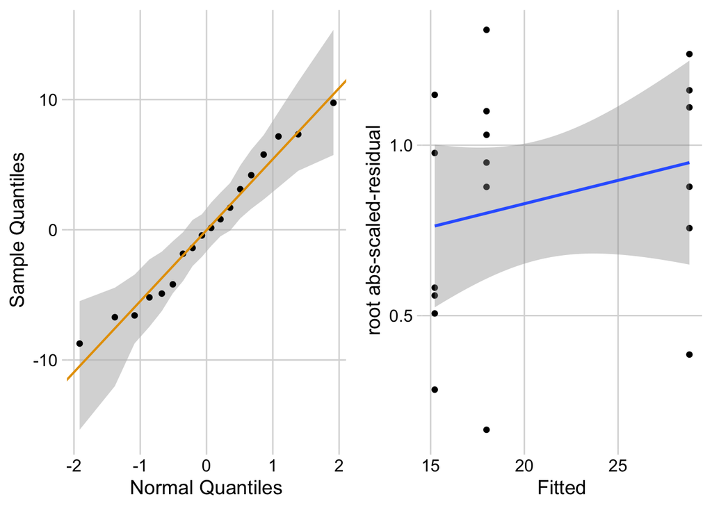

```r
ggcheck_the_model(m1_fig1g)
```

```r
emm_fig1g <- emmeans(m1_fig1g, specs = "treatment")
pairs_fig1g <- contrast(emm_fig1g,
         method = "revpairwise",
         adjust = "tukey") %>%
  summary(infer = TRUE)
pairs_fig1g
```

```
##  contrast    estimate   SE df lower.CL upper.CL t.ratio p.value
##  Con - Naive    13.59 3.34 15     4.90    22.27   4.062  0.0028
##  Amp - Naive     2.76 3.34 15    -5.93    11.45   0.826  0.6933
##  Amp - Con     -10.82 3.34 15   -19.51    -2.13  -3.236  0.0144
##
## Confidence level used: 0.95
## Conf-level adjustment: tukey method for comparing a family of 3 estimates
## P value adjustment: tukey method for comparing a family of 3 estimates
```

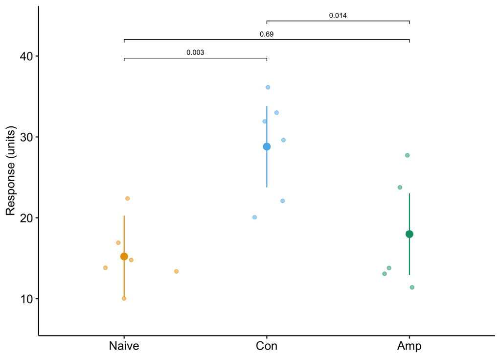

```r
ggplot_the_response(m1_fig1g, emm_fig1g, pairs_fig1g)
```

3. Plot the model using ggplot_the_response. Give the plot pretty x-axis and y-axis labels. See the section in the [Plotting Models](https://www.middleprofessor.com/files/bio413/applied_biostatistics/plotting-models.html#how-to-use-the-plot-the-model-functions) chapter in the textbook on using ggplot_the_response to understand the arguments of the functions. This plot will look something like the published plot but will be a little different and better.
4. Better than reproducibility - What would you change to better analyze and/or communicate? If there are changes, do this.
5. Write a short statement communicating the inference – something more formal than what the authors wrote. Here is what the authors wrote:

Author summary: “Importantly, MOG-specific cytokine production and proliferation of CD4+ T cells in the small intestine were reduced by oral treatment with ampicillin (Fig. 1e, f)” [JAW: I think they also mean to add 1g here since they don’t refer to it later and 1g is just the raw count data for 1f]

# Part II. Induction of osteogenesis by bone-targeted Notch activation

The assignment is: reproduce the analysis of the experiment presented in Fig. 6c of the article

Source article: [Induction of osteogenesis by bone-targeted Notch activation](https://elifesciences.org/articles/60183)

dataset: “Xu fig 6c.xlsx”

You need to 1) import the data, 2) analyze the data, and 3) report the results following the example in [Section 10.1.1](https://www.middleprofessor.com/files/applied-biostatistics_bookdown/_book/oneway#oneway-example1)

About the data: **Dll4(E12)** is a high affinity version of the [Notch] ligand Delta-like 4. Dll4(E12) increases osteogenesis in male mice (Fig. 3). This leads to…

Why are they doing this experiment? “Next, we investigated whether Dll4(E12) treatment provides any beneficial effects in the ovariectomy model of postmenopausal osteoporosis.”

Response variable: Connectivity Density (the top-right panel of 6c)

1. Factor 1: *ovx* with levels = (“Sham”, “Ovx”)
- Sham –sham surgery.
- Ovx – ovariectomy.
2. Factor 2: *dll4* with levels = (“Dll4_neg”, “Dll4_pos”)
- dll4_neg – no drug or “vehicle”
- dll4_pos – drug

Groups:

1. Sham/dll4_neg – the negative control giving the background bone measures
2. Ovx/dll4_nex – the positive ovx control. We know that ovx creates osteoporosis like bone measures.
3. Sham/dll4_pos – the positive dll4 control. In males, dll4 induces osteogenesis but we don’t know this for females, so this is positive in the sense in this is what happens when we give dll4 in the Sham background.
4. Ovx/dll4_pos – the focal treatment. Does dll4 “rescue” the effects of ovariectomy on osteoporosis?

Assignment:

1. Write out all contrasts and which are of interest and which are not, and why for both.
2. Reproduce the statistics given by the authors for the analysis in Fig. 6c, **including the ANOVA table and the table of contrasts**. They published the statistics in the original excel file. I’ve copied and pasted the statistics into the Excel file I’ve provided, on the same sheet as the data. You want your statistics to match these.
3. Plot the model using ggplot_the_response. Give the plot pretty x-axis and y-axis labels. See the section in the [Plotting Models](https://www.middleprofessor.com/files/bio413/applied_biostatistics/plotting-models.html#how-to-use-the-plot-the-model-functions) chapter in the textbook on using ggplot_the_response to understand the arguments of the functions. This plot will look something like the published plot but will be a little different and better.
4. Better than reproducibility - What would you change to better analyze and/or communicate? If there are changes, do this.
5. Write a short statement communicating the inference – something more formal than what the authors wrote. Here is what the authors wrote:

Author summary: “In comparison to sham controls, ovariectomized female mice show significant reduction of trabecular bone, which is not improved by Dll4(E12) expression (Figure 6A–D).”

```r
data_from <- "Induction of osteogenesis by bone-targeted Notch activation"
file_name <- "Xu fig 6c.xlsx"
file_path <- here(data_folder, data_from, file_name)
fig6c <- read_excel(file_path,
                    sheet = "fig 6c",
                    range = "A1:E21") %>%
  clean_names() %>%
  data.table()
dll4_levels <- c("Dll4_neg", "Dll4_pos")
fig6c[, dll4 := factor(dll4,
                       levels = dll4_levels)]

ovx_levels <- c("Sham", "OVX")
fig6c[, ovx := factor(ovx,
                       levels = ovx_levels)]
```

```r
type3 <- list(
  dll4 = contr.sum,
  ovx = contr.sum
)
m1_anova_fig6c <- lm(connectivity ~ dll4 * ovx,
                     contrasts = type3,
                     data = fig6c)
Anova(m1_anova_fig6c, type = "3")
```

```
## Anova Table (Type III tests)
##
## Response: connectivity
##             Sum Sq Df  F value   Pr(>F)
## (Intercept) 370885  1 147.6029 1.72e-09 ***
## dll4            89  1   0.0353 0.853281
## ovx          34397  1  13.6893 0.001943 **
## dll4:ovx     13975  1   5.5616 0.031415 *
## Residuals    40204 16
## ---
## Signif. codes:  0 '***' 0.001 '**' 0.01 '*' 0.05 '.' 0.1 ' ' 1
```

```r
emm_fig6c <- emmeans(m1_anova_fig6c, specs = c("dll4", "ovx"))
pairs_fig6c <- contrast(emm_fig6c,
                        method = "revpairwise",
                        adjust = "tukey") %>%
  summary(infer = TRUE)
pairs_fig6c
```

```
##  contrast                      estimate   SE df lower.CL upper.CL t.ratio
##  Dll4_pos Sham - Dll4_neg Sham    -57.1 31.7 16     -148    33.62  -1.800
##  Dll4_neg OVX - Dll4_neg Sham    -135.8 31.7 16     -227   -45.11  -4.284
##  Dll4_neg OVX - Dll4_pos Sham     -78.7 31.7 16     -169    11.97  -2.483
##  Dll4_pos OVX - Dll4_neg Sham     -87.2 31.7 16     -178     3.55  -2.749
##  Dll4_pos OVX - Dll4_pos Sham     -30.1 31.7 16     -121    60.63  -0.949
##  Dll4_pos OVX - Dll4_neg OVX       48.7 31.7 16      -42   139.36   1.535
##  p.value
##   0.3089
##   0.0029
##   0.1010
##   0.0619
##   0.7795
##   0.4412
##
## Confidence level used: 0.95
## Conf-level adjustment: tukey method for comparing a family of 4 estimates
## P value adjustment: tukey method for comparing a family of 4 estimates
```

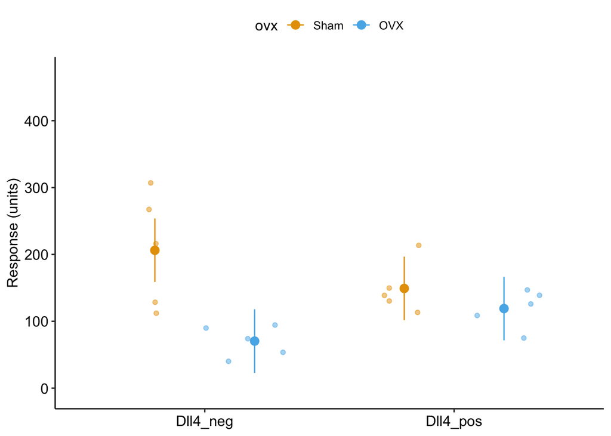

```r
fig6c_pic <- ggplot_the_response(m1_anova_fig6c, emm_fig6c, pairs_fig6c)
fig6c_pic
```

How I would do it

```r
m1_fig6c <- lm(connectivity ~ dll4 * ovx,
                     data = fig6c)
```

1. The easy way to get the interaction

```r
summary(m1_fig6c) |>
  coef()
```

```
##                      Estimate Std. Error   t value     Pr(>|t|)
## (Intercept)          206.1890   22.41751  9.197676 8.680059e-08
## dll4Dll4_pos         -57.0806   31.70315 -1.800471 9.066607e-02
## ovxOVX              -135.8100   31.70315 -4.283802 5.695723e-04
## dll4Dll4_pos:ovxOVX  105.7346   44.83502  2.358304 3.141511e-02
```

```r
emm_fig6c <- emmeans(m1_fig6c,
                     specs = c("dll4", "ovx"))
```

```r
control <- c(1, 0, 0, 0)
dll4 <- c(0, 1, 0, 0)
ovx <- c(0, 0, 1, 0)
both <- c(0, 0, 0, 1)

# effect of dll4 with and without ovx
#( both - ovx)  = effect of dll4 with ovx
# (dll4 - control) = effect of dll4 without ovx
planned <- list(
  "dll4 - control" = dll4 - control,
  "ovx - control" = ovx - control,
  "interaction" = (both - ovx) - (dll4 - control)
)

planned_fig6c <- contrast(emm_fig6c,
                          method = planned,
                          adjust = "none") |>
  summary(infer = TRUE)
planned_fig6c
```

```
##  contrast       estimate   SE df lower.CL upper.CL t.ratio p.value
##  dll4 - control    -57.1 31.7 16   -124.3     10.1  -1.800  0.0907
##  ovx - control    -135.8 31.7 16   -203.0    -68.6  -4.284  0.0006
##  interaction       105.7 44.8 16     10.7    200.8   2.358  0.0314
##
## Confidence level used: 0.95
```

```r
summary(m1_fig6c) |>
  coef()
```

```
##                      Estimate Std. Error   t value     Pr(>|t|)
## (Intercept)          206.1890   22.41751  9.197676 8.680059e-08
## dll4Dll4_pos         -57.0806   31.70315 -1.800471 9.066607e-02
## ovxOVX              -135.8100   31.70315 -4.283802 5.695723e-04
## dll4Dll4_pos:ovxOVX  105.7346   44.83502  2.358304 3.141511e-02
```